# Activity assay of 3D HPLC fractions for James

Jan Sklenar

22/5/2021

## Goals

Visualize and compare the activity profiles of purified extract. Samples are parallel 3D HPLC separations yielding sets of fractions. Measurements of each fraction are carried out in relicates (n=4).

## Protocol

- Extraction
- Preseparation steps
- 3D LC separation
- Activity assay - gene expression

The activity of fractions are visualized here.

## Data preparation

### Read data into R

```r
## read in raw data and some annotation
setwd("C:/0_R/210522_James_activity/")
raw <- read.csv("data/summary_18-05-21_edit_ACTIVITY.csv", skip = 7, stringsAsFactors = FALSE)
str(raw)
colnames(raw)
dim(raw)
head(raw)
tail(raw)
# get rid of NAs
#raw <- raw[complete.cases(raw),]
dim(raw)
```

### Rename columns

```r
#mynames <- c("Reading","MeasTimeSec",
#             paste(rep("reaction_1",4),"-",seq(1:4)),
#             paste(rep("reaction_2",4),"-",seq(1:4)),
#             paste(rep("reaction_3",4),"-",seq(1:4)),
#             paste(rep("reaction_4",4),"-",seq(1:4)),
#             paste(rep("reaction_5",4),"-",seq(1:4)),
#             paste(rep("reaction_6",4),"-",seq(1:4)))
#mynames
#names(raw) <- mynames

colnames(raw)
# data I need
S <- colnames(raw)[grep("S\\d", colnames(raw))]
min <- colnames(raw)[grep("min", colnames(raw))]
mydata=c(min,S)
mydata

df <- raw[,mydata]
dim(df)
dim(df[complete.cases(df),])
```

### Common annotations to be used in plots

Sample names and conditions for plot legends.

```r
title  <- "3D-LC fractions"
mysubtitle <- "May 2021"
name <- "replicates:"
IDs <- as.character(seq(1:4))
mycolours <- c("yellow","red","blue","green")#,"lightblue2","lightblue3")
mylabels <-  c("one",
             "two",
             "three",
             "four")
mylabels <- paste(IDs, mylabels, sep=": ")
names(mylabels) <- IDs
```

### Conversion to a long data format

```r
df_long <- gather(df, key = "Sample", value = "RFU", -"min")
head(df_long)
table(is.na(df_long))
#df[is.na(df),]
```

### Parse the sample names to create variables

```r
#' remove columns if necessary
colnames(df_long)

#' parse 'Sample' to obtain sample number 'SampleNo'
df_long$Sample[1]

df_long$SampleNo <- substr(df_long$Sample,2,regexpr('_', df_long$Sample)-1)

df_long$RepNo <- substr(df_long$Sample,regexpr('_', df_long$Sample)+1,regexpr('F', df_long$Sample)-2)

df_long$FracNo <- substr(df_long$Sample,regexpr('F', df_long$Sample), length(df_long$Sample))

head(df_long)

#' in the same way extract replicate number - 'RepNo'
#df$RepNo <- substr(df$Sample,regexpr(' - ', df$Sample)+3, regexpr('$', df$Sample))
#head(df$RepNo)

# #' Change sec to min
# table(is.na(df$MeasTimeSec))
# df$MeasTimeMin <- df$MeasTimeSec/60
# head(df$MeasTimeMin)
# #' remove white space from 'Well' sting
# #df$Well<- substr(df$Well, 2, regexpr('$', df$Well))

#' convert SampleNo to factor in order it to sort nicely in ggplots
df_long$SampleNo <- as.factor(df_long$SampleNo)
df_long$SampleNo <- factor(df_long$SampleNo, levels=IDs)
unique(df_long$SampleNo)
head(df_long)
```

### Subset of data for plotting if necessary

```r
# # Selected (cleaned) data contains only columns needed for plotting
# # Well, Sample, SampleNo, RepNo, MeasTimeSec, RFU
# colnames(df)
# df <- df[,c(1,2,3,4,5,6,7)]
# head(df)
# # there should be no missing values
# table(is.na(df))
# df[!complete.cases(df),]
```

## Plots

### All the data

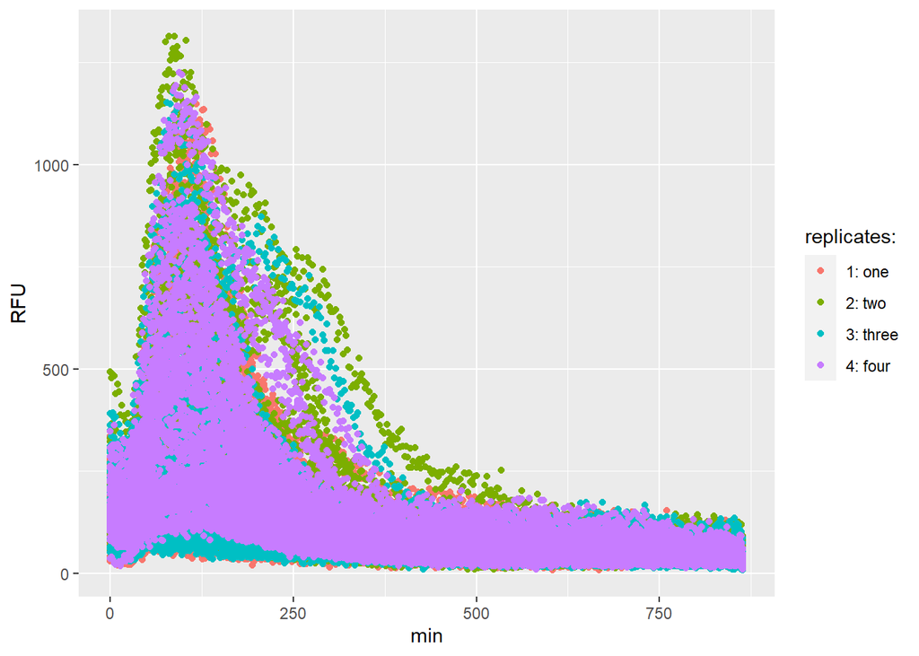

```r
# all the data
head(df_long)
#plot(x=df_long$min,y=df$RFU)

# colour by samples
ggplot(data = df_long) +
  aes(x = min, y=RFU) +
  geom_point(aes(color=SampleNo)) +
  scale_color_discrete(name=name, breaks=IDs, labels=mylabels)
```

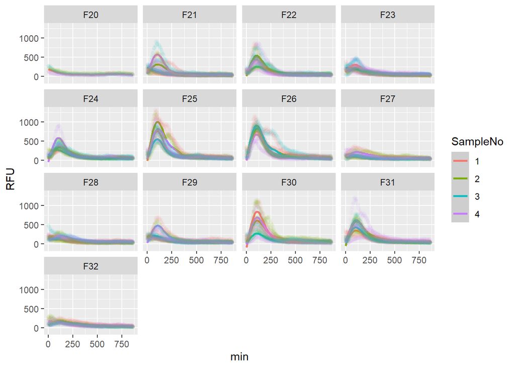

```r
ggplot(data = df_long) +
  aes(x = min, y=RFU) +
  geom_smooth(aes(color=SampleNo), method = 'gam',se=T, level=0.95) +
  geom_point(aes(color=RepNo), alpha=1/50) +
  facet_wrap(~FracNo, scales = "fixed")
```

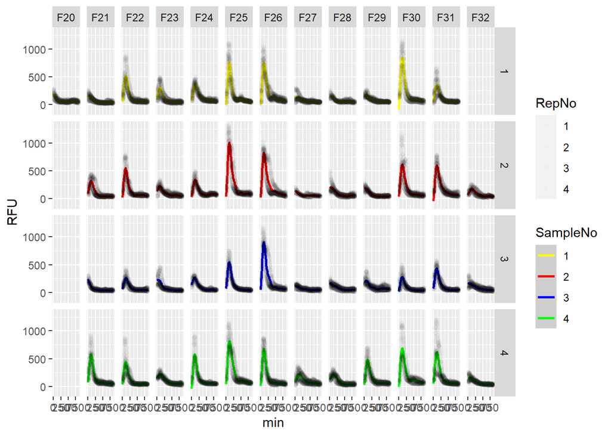

```r
ggplot(data = df_long) +
  aes(x = min, y=RFU) +
  geom_smooth(aes(color=SampleNo), method = 'gam',se=T, level=0.95) + scale_color_manual(values = mycolours) +
  geom_point(aes(fill=RepNo), alpha=1/100) +
  #scale_color_manual(values = mycolours) +
  scale_fill_manual(values = mycolours) +
  facet_grid(SampleNo~FracNo, scales = "fixed")
```

### Data adjustments if necessary

Removal of bad replicates and outliers

```r
## Adjustments - remove outliers if necessary

## Sometimes samples needs to be combined...
#  df$SampleComb <- df$SampleNo
#  df[df$SampleComb==2,"SampleComb"] <- 1

## Measurement of this sample have many outliers...
#  ggplot(subset(df, SampleNo %in% c(7))) +
#  aes(x = MeasTimeSec, y=RFU) +
#  geom_point(aes(color=SampleNo))

## Use summary statistics (mean) to find and remove obvious outliers...

# #  means of all replicates
# dfstat <- df %>% filter(SampleNo==1|SampleNo==2|SampleNo==3|SampleNo==4|SampleNo==5|SampleNo==6) %>% group_by(SampleNo,RepNo) %>% summarise(mean=mean(RFU))
# print(dfstat,n=nrow(dfstat))
# #View(dfstat)



# Data that should be removed
#dim(df)
#dim(df %>% filter(RepNo==1))
#dim(df %>% filter(RepNo!=1))
#df <- df %>% filter(RepNo!=1)

## To invert filter...
#  filter(df,SampleNo == 7 & RepNo == 3)
#  It is the same as leaving out all the measurement from some wells
#  df <- filter(df, Well != "A01" & Well != "B01" & Well != "C01"&  Well != "D01"& Well != "E01"& Well != "F01" & Well != "G01"& Well != "H01")

## Filter can be also inverted using...
#  df <- filter(df, Well != "G03")

## To remove some data...
#  There are some zeros (negative spikes) in Sample "7 1/3"
#  Let's removethose  zeros here
#  df[which(df$Sample=="7 1/3"&df$RFU==0),]
#  dfs[which(dfs$Sample=="7 1/3"&dfs$RFU==0),] <- NA

## Checks...
head(df_long)
length(rownames(df_long))
length(complete.cases(df_long))
table(is.na(df_long))
## only complete cases
df[which(is.na(df_long)),]
df_long_clean <- df_long[complete.cases(df_long),]
## check for NAs
dim(df_long)
dim(df_long_clean)
table(is.na(df_long))
table(is.na(df_long_clean))
```

### Panels of plots

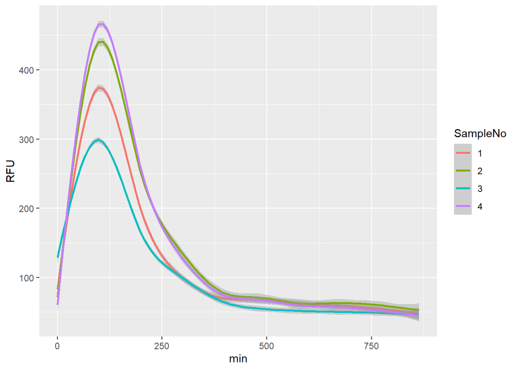

```r
## LOESS regression,

p <- ggplot(data = df_long) +
  aes(x = min, y=RFU) +
  geom_smooth(aes(color=SampleNo), method = 'gam',se=T, level=0.95) #+geom_point(aes(colour=RepNo))
p
```

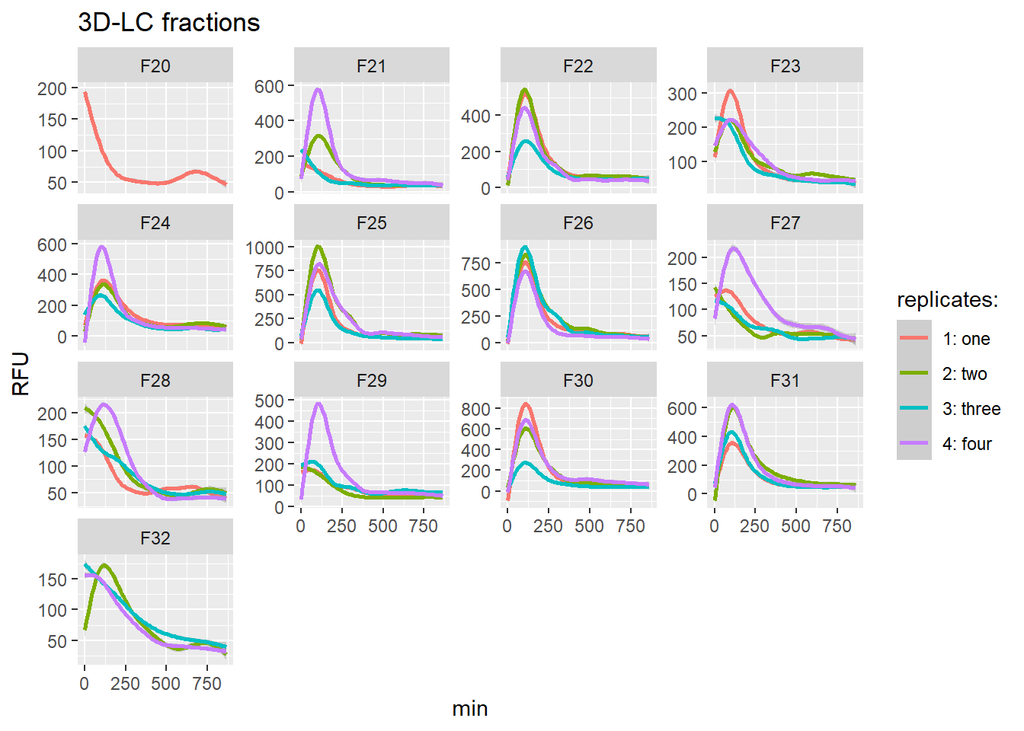

```r
## Panel of plots fixed scale
p+facet_wrap(~FracNo, scales = "free_y") + #coord_cartesian(xlim = c(0,500)) +
  labs(title = title, x = "min", y = "RFU") +
  scale_colour_discrete(name=name, breaks=IDs, labels=mylabels)
```

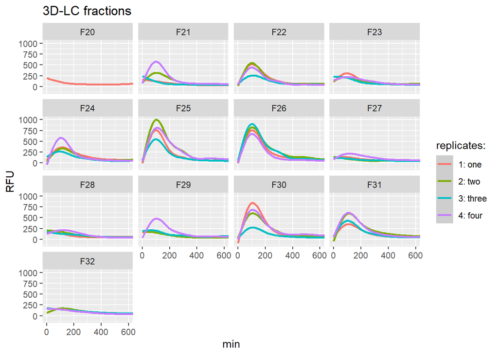

```r
## Panel of plots of Fractions - zoomed
p+facet_wrap(~FracNo, scales = "fixed") +
  coord_cartesian(xlim = c(0,600)) +
  labs(title = title, x = "min", y = "RFU") +
  scale_colour_discrete(name=name, breaks=IDs, labels=mylabels)
```

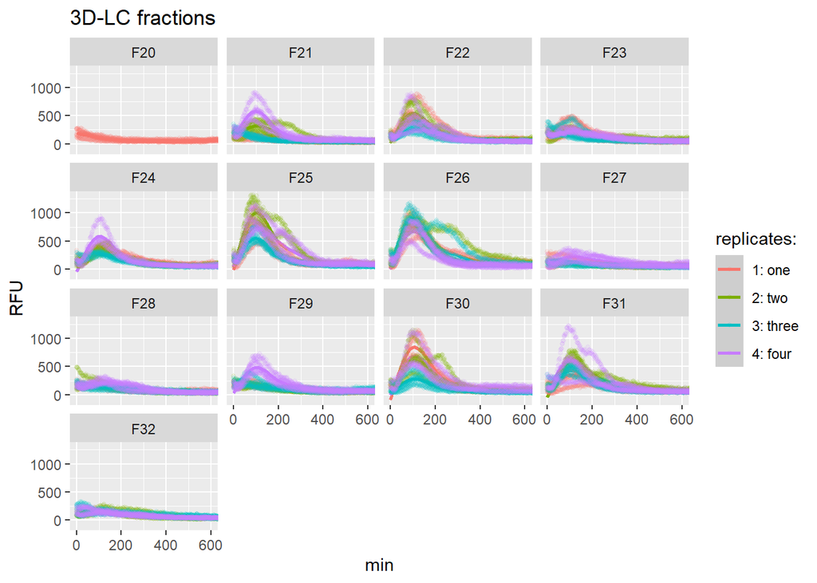

```r
## Panel of plots of Fractions - zoomed
# adding the actual points
p + geom_point(aes(colour=SampleNo), size = 1, alpha=1/10) + facet_wrap(~FracNo, scales = "fixed") +  coord_cartesian(xlim = c(0,600)) +
  labs(title = title, x = "min", y = "RFU") +
  scale_colour_discrete(name=name, breaks=IDs, labels=mylabels)
```

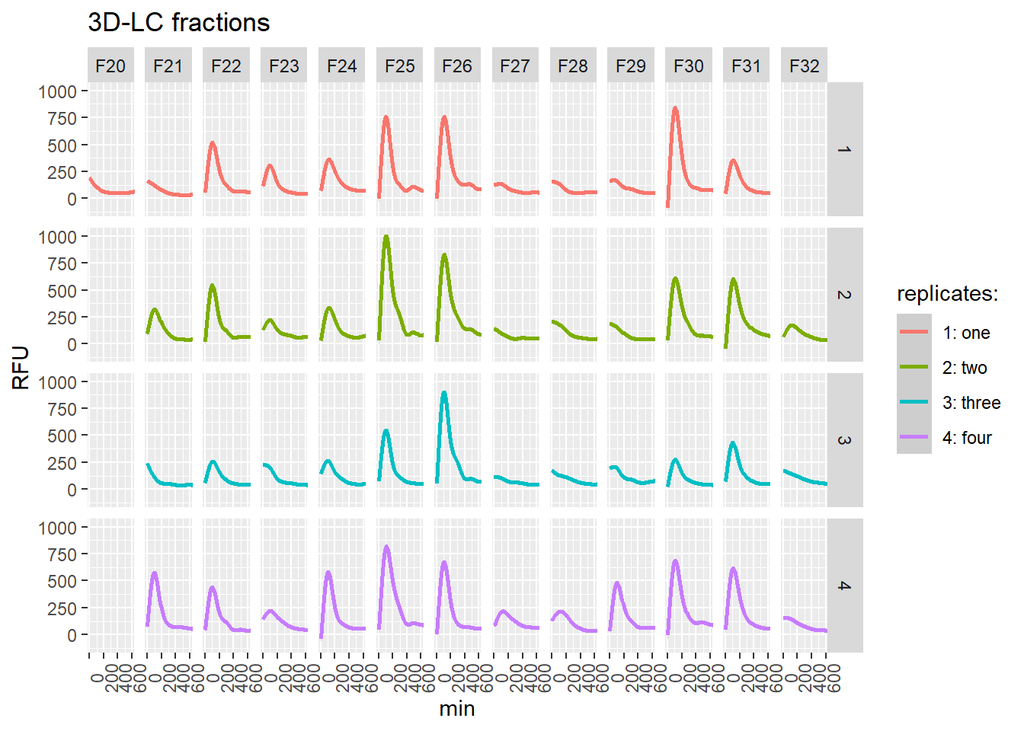

```r
## Grid of plots of Samples~Fractions - zoomed
p + facet_grid(SampleNo~FracNo, scales = "fixed") +
  coord_cartesian(xlim = c(0,600)) +
  labs(title = title, x = "min", y = "RFU") +
  scale_colour_discrete(name=name, breaks=IDs, labels=mylabels) +
theme(axis.text.x = element_text(angle=90))
```

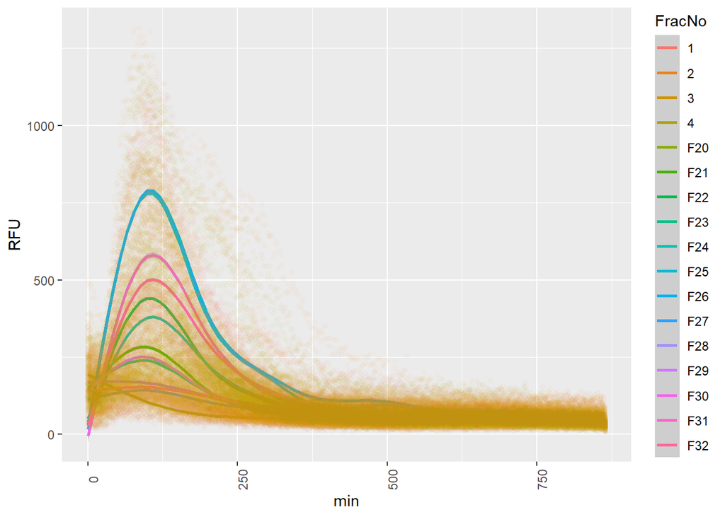

```r
## With data points
q <- ggplot(data = df_long) + #[df_long$FracNo=="F25",]) +
  aes(x = min, y=RFU) +
  geom_smooth(aes(color=FracNo), method = "gam") + geom_point(aes(colour=SampleNo), alpha=1/30) +
  theme(axis.text.x = element_text(angle=90))
q
```

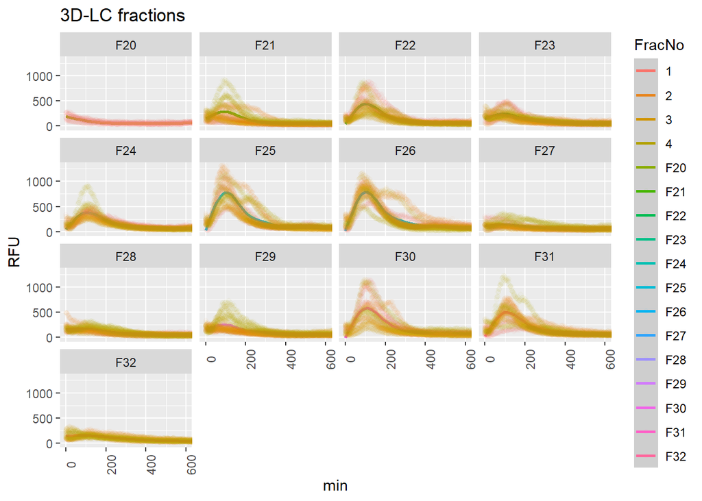

```r
## Panel of plots of Fractions - zoomed, samples combined
q+facet_wrap(~FracNo, scales = "fixed") +
  coord_cartesian(xlim = c(0,600)) +
  labs(title = title, x = "min", y = "RFU")
```

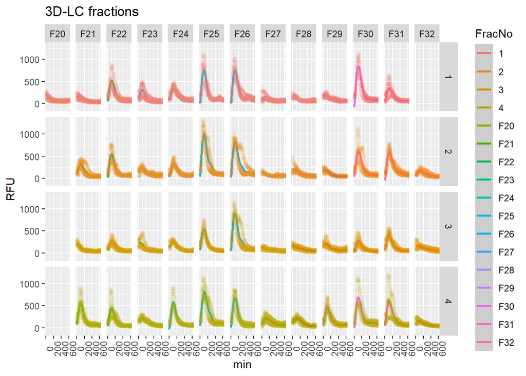

```r
q+facet_grid(SampleNo~FracNo, scales = "fixed") +
  coord_cartesian(xlim = c(0,600)) +
  labs(title = title, x = "min", y = "RFU") +
  theme(axis.text.x = element_text(angle=90))
```

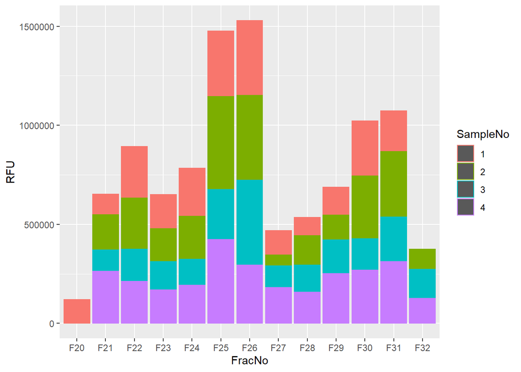

```r
## Sums for comparision

ggplot(data = df_long) +aes(x=FracNo, y=RFU)+ geom_col(aes(color=SampleNo))
```

### Observations

- Despite the signal magnitude is quite reproducible, we observe the differnet expression profiles among the replicates (of the same fraction). For that reason many data point do not fall into 95% the confidence intervals.
- Summing up averages hides the differences in the data - it is a general problem that many small values can hide a peak! For that reason, it seems better to sum the replicates, then take average/smooth with the other replicates.  
  There is a MS technique we use; when we trust our signal we acquire and sum up enough spectra to suppress the noise. Then we can take several of such measurements for error calculation.
- It is better to show the peaks in an array of plots than the sums.
- We can also observe and compare the individual replicates. They are not always exactly the same.

### Some more playing with the data

```r
#head(df,10)
head(df_long,10)
library("dplyr")
df_long_sum <- df_long %>% group_by(SampleNo,FracNo,min) %>% summarise(RFU=sum(RFU, na.rm = TRUE))
```

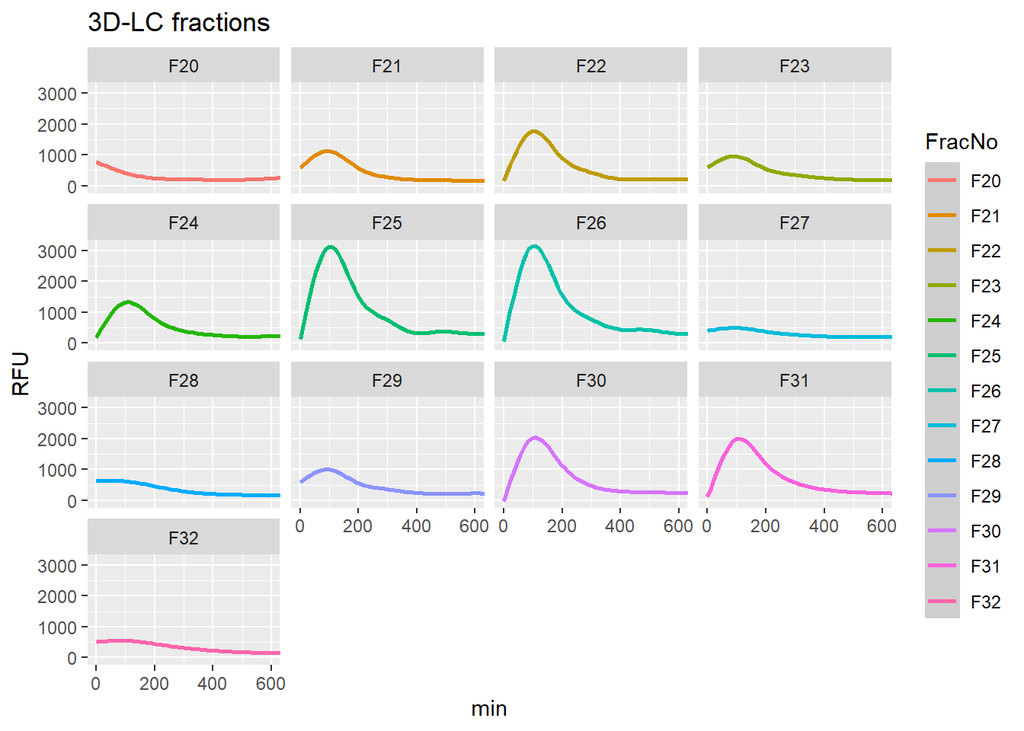

```r
## With data points
q <- ggplot(data = df_long_sum) + #[df_long$FracNo=="F25",]) +
  aes(x = min, y=RFU) +
  geom_smooth(aes(color=FracNo), method = "gam")

#q

## Panel of plots of Fractions - zoomed, samples combined
q+facet_wrap(~FracNo, scales = "fixed") +
  coord_cartesian(xlim = c(0,600)) +
  labs(title = title, x = "min", y = "RFU")
```

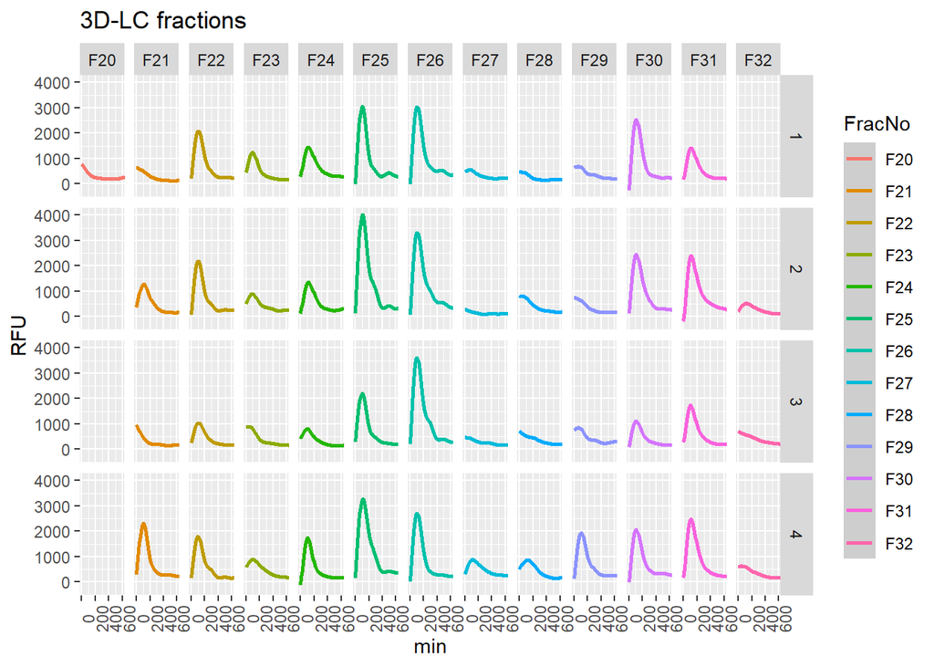

```r
q+facet_grid(SampleNo~FracNo, scales = "fixed") +
  coord_cartesian(xlim = c(0,600)) +
  labs(title = title, x = "min", y = "RFU") +
  theme(axis.text.x = element_text(angle = 90))
```

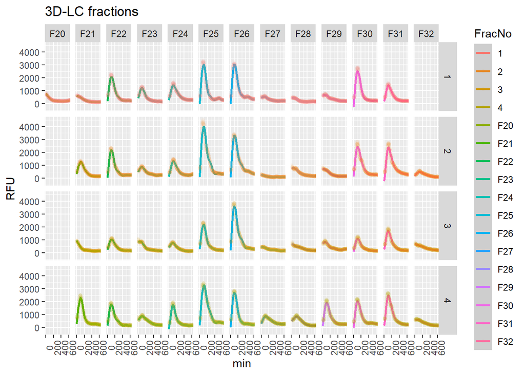

```r
q+facet_grid(SampleNo~FracNo, scales = "fixed") +
  coord_cartesian(xlim = c(0,600)) +
  labs(title = title, x = "min", y = "RFU") +
  theme(axis.text.x = element_text(angle = 90)) +
  geom_point(aes(colour=SampleNo), alpha=1/30)
```